# chapter4.Rmd

# K-mean clustering and cluster visualization

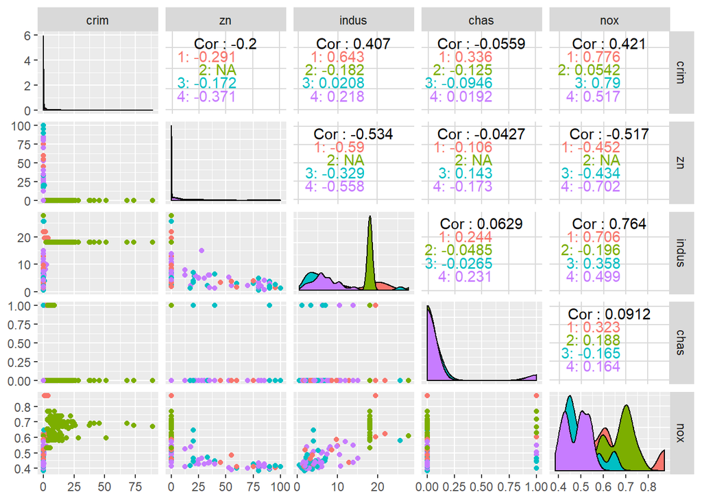

```
##  [1] 19401064.0  5764994.3  3068499.5  4147217.1  3956185.3  3860032.6
##  [7]  3500888.6   894885.6   804919.4   748120.4  1021056.7   690624.8
## [13]   684461.7   611890.8   617447.6
```

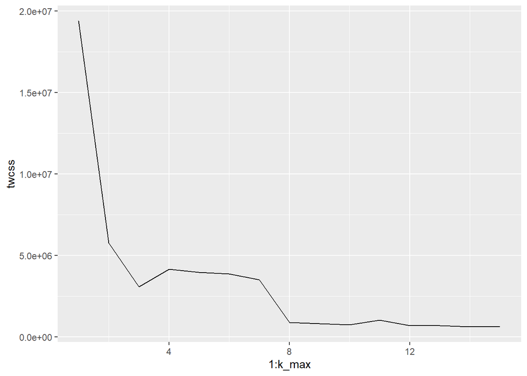

The total of within cluster sum of squares (TWCSS) changes radically by moving from 1 to 2 clusters. So 2 clusters is probably the most optimal cluster number.

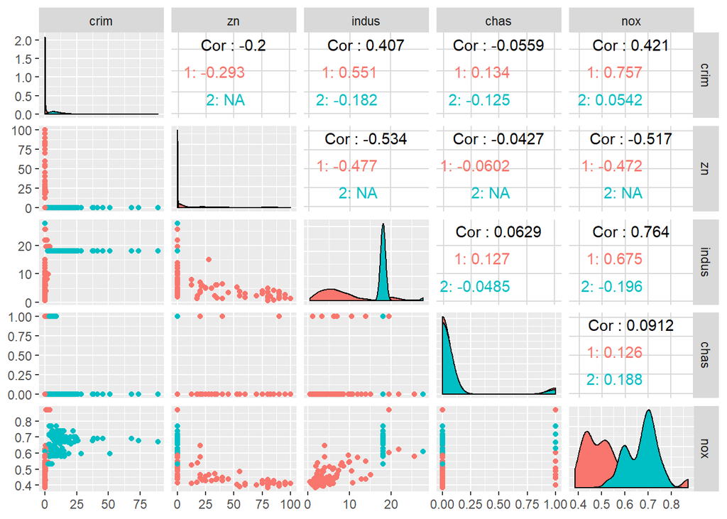

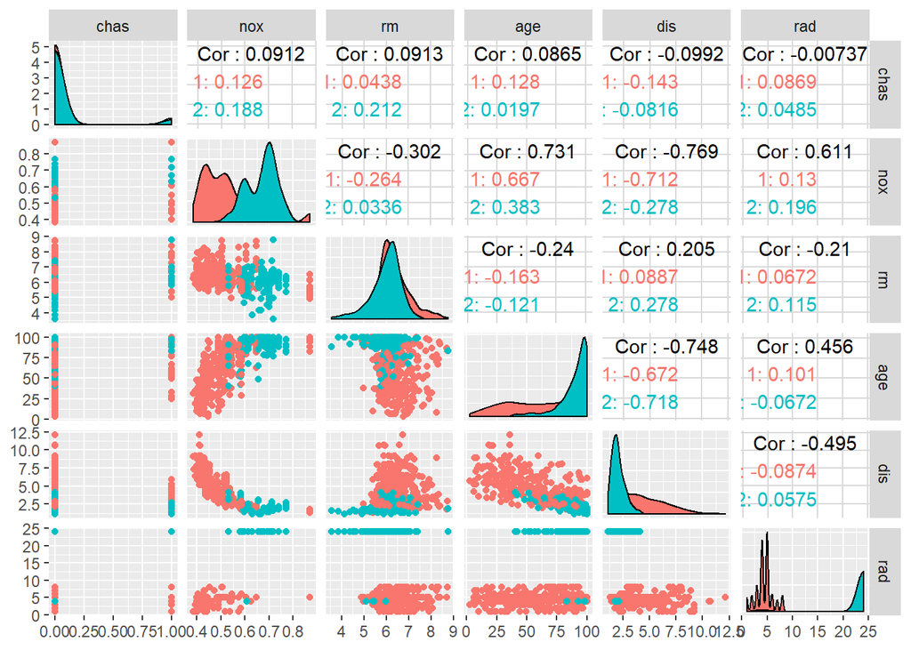

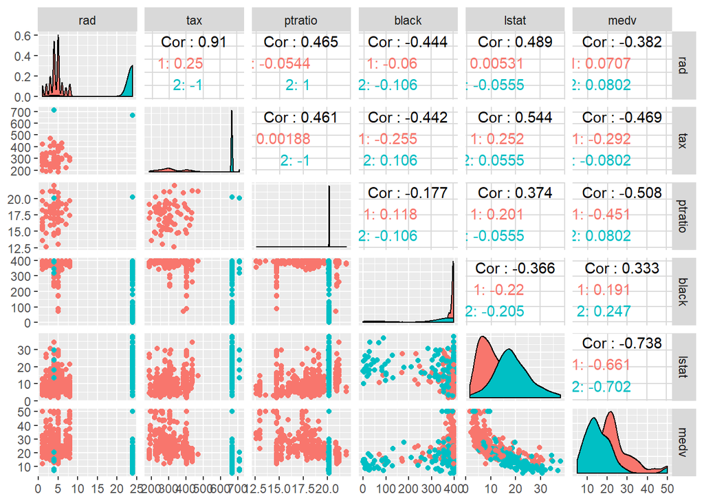

[output not shown]

[figure not shown]

The variables crim, rad and tax seem to clearly characterize the clusters since the two clusters are clearly distinguished.

# References

Paul E. Black, “Manhattan distance”, in Dictionary of Algorithms and Data Structures [online], Paul E. Black, ed. 11 February 2019. (accessed TODAY) Available from: https://www.nist.gov/dads/HTML/manhattanDistance.html